# Taller 3 - Análisis Avanzado de Datos

## Problema 2

La Universidad de California Irvine (UCI) tiene un repositorio de datos de ejemplo para el uso de machine learning y aprendizaje estadístico. Uno de los conjuntos de datos es el denominado Heart Disease.

Con el conjunto de datos completo, construya un modelo de regresión logístico con función de enlace logit tomando como respuesta la presencia de la enfermedad cardiaca, use las demás variables como explicativas en el modelo de regresión. Revise las URL dadas para la definición de cada una de las variables y note que debe obtener la variable respuesta categorizando una de las variables del conjunto de datos. Siga los siguientes pasos en la realización del ejercicio:

### 1. Imputar datos

El conjunto de datos tiene datos perdidos en algunas variables. Estos están notados con un ?. Impute los valores perdidos como la mediana de los datos para las variables correspondientes.

En primer lugar cargamos los datos desde la URL indicada:

```r
# Definir la URL del archivo de datos
url <- "http://archive.ics.uci.edu/ml/machine-learning-databases/heart-disease/processed.cleveland.data"

# Leer los datos desde la URL
datos <- read.table(url, sep = ",")

# Ajustar varaible objetivo

datos$V14 <- (datos$V14 > 0)*1

# Imprimir los primeros registros de los datos
head(datos)
```

```
##   V1 V2 V3  V4  V5 V6 V7  V8 V9 V10 V11 V12 V13 V14
## 1 63  1  1 145 233  1  2 150  0 2.3   3 0.0 6.0   0
## 2 67  1  4 160 286  0  2 108  1 1.5   2 3.0 3.0   1
## 3 67  1  4 120 229  0  2 129  1 2.6   2 2.0 7.0   1
## 4 37  1  3 130 250  0  0 187  0 3.5   3 0.0 3.0   0
## 5 41  0  2 130 204  0  2 172  0 1.4   1 0.0 3.0   0
## 6 56  1  2 120 236  0  0 178  0 0.8   1 0.0 3.0   0
```

Como se indicó, los datos nulos se identifican mediante el simbolo ?, por lo tanto se remplaza dicho simbolo con nulos.

```r
datos[datos == "?"] <- NA
```

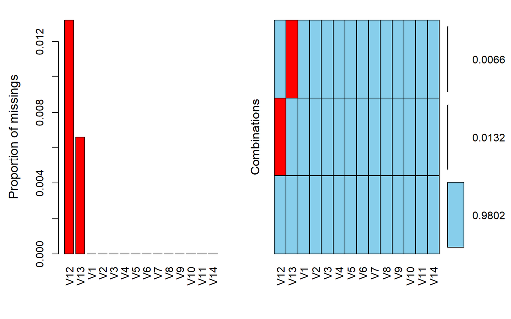

```
##
##  Variables sorted by number of missings:
##  Variable      Count
##       V12 0.01320132
##       V13 0.00660066
##        V1 0.00000000
##        V2 0.00000000
##        V3 0.00000000
##        V4 0.00000000
##        V5 0.00000000
##        V6 0.00000000
##        V7 0.00000000
##        V8 0.00000000
##        V9 0.00000000
##       V10 0.00000000
##       V11 0.00000000
##       V14 0.00000000
```

```r
#install.packages("VIM")
library(VIM)
aggr(datos,numbers=T,sortVar=T)
```

Se imputan los valores perdidos como la mediana de los datos para las variables V12 y V13 respectivamente.

```r
datos$V12 <- as.numeric(datos$V12)
datos$V13 <- as.numeric(datos$V13)
datos$V12[is.na(datos$V12)] <- median(datos$V12, na.rm = TRUE)
datos$V13[is.na(datos$V13)] <- median(datos$V13, na.rm = TRUE)
```

### 2. Revisar las distribuciones bivariadas

Revise la distribución de la variable respuesta para cada una de las covariables categoricas de manera bivariada. ¿observa algún inconveniente con alguna de las variables al hacer el análisis?.

Al realizar las distribuciones bivariadas de las variables categóricas con respecto a la variable objetivo se observa:

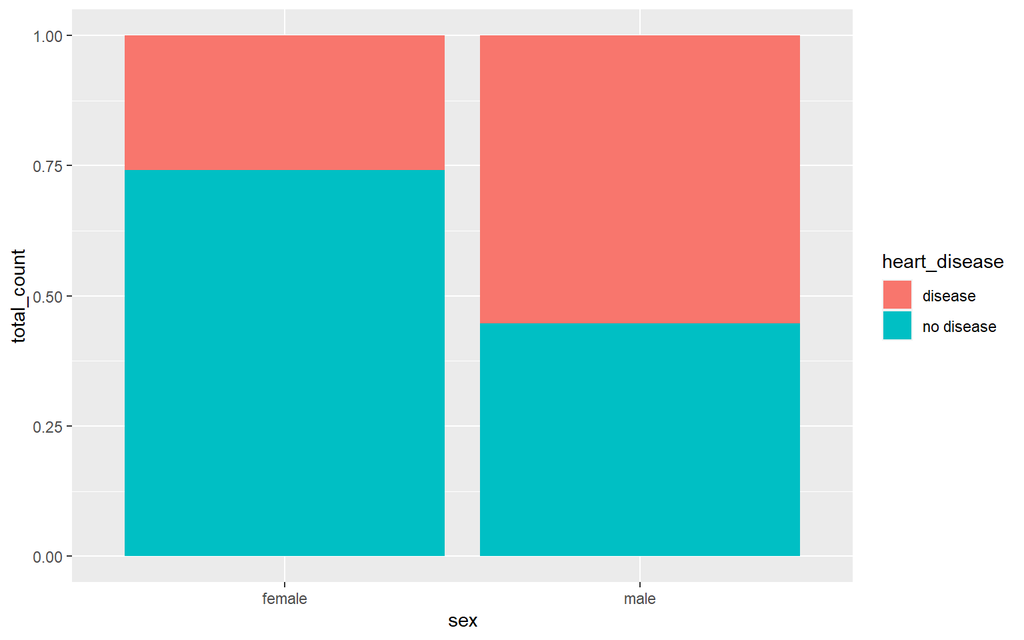

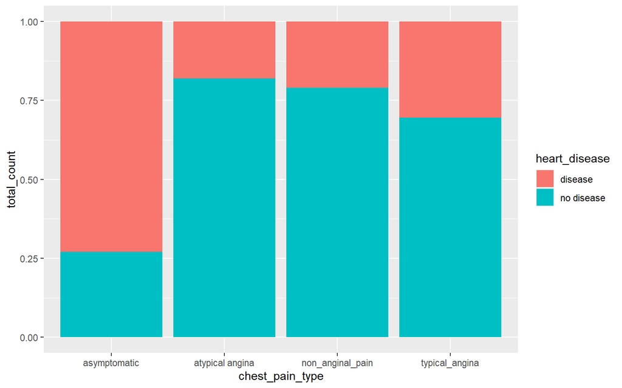

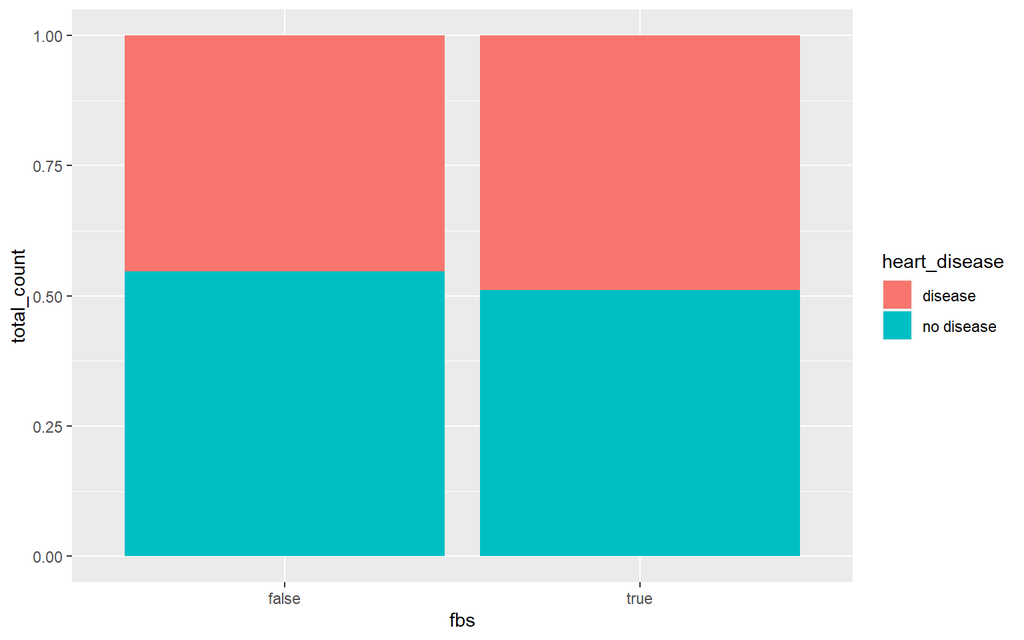

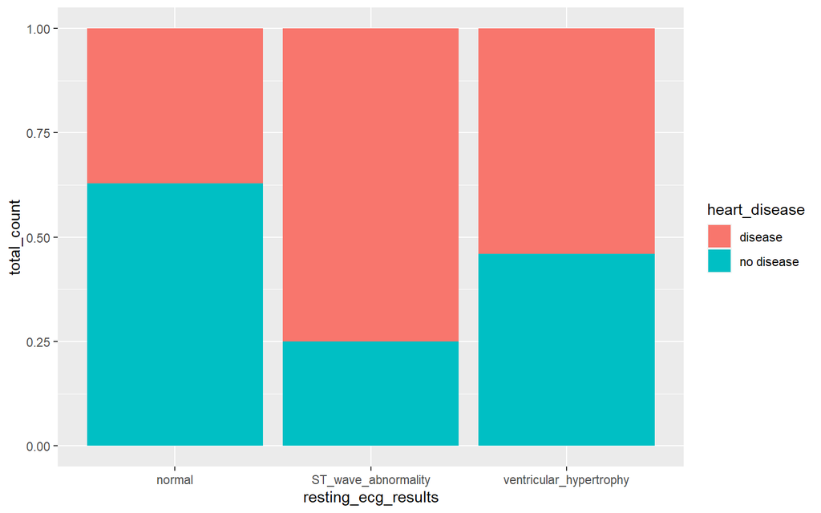

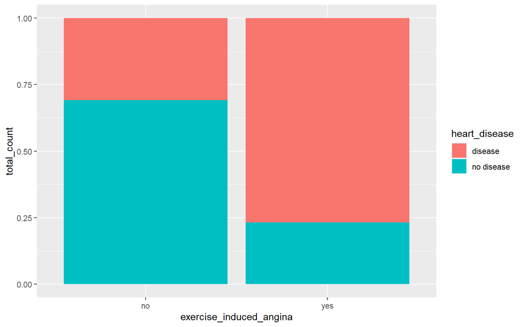

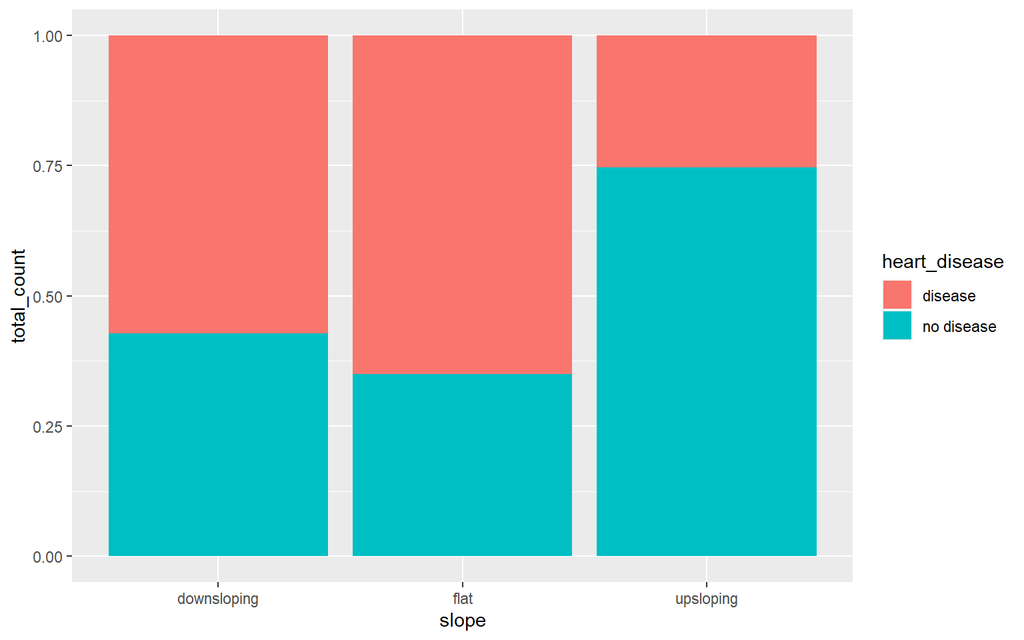

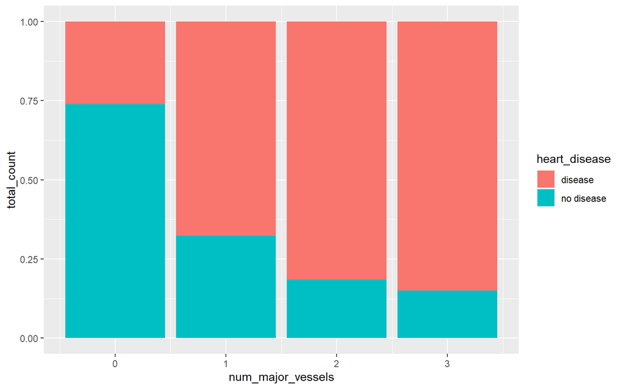

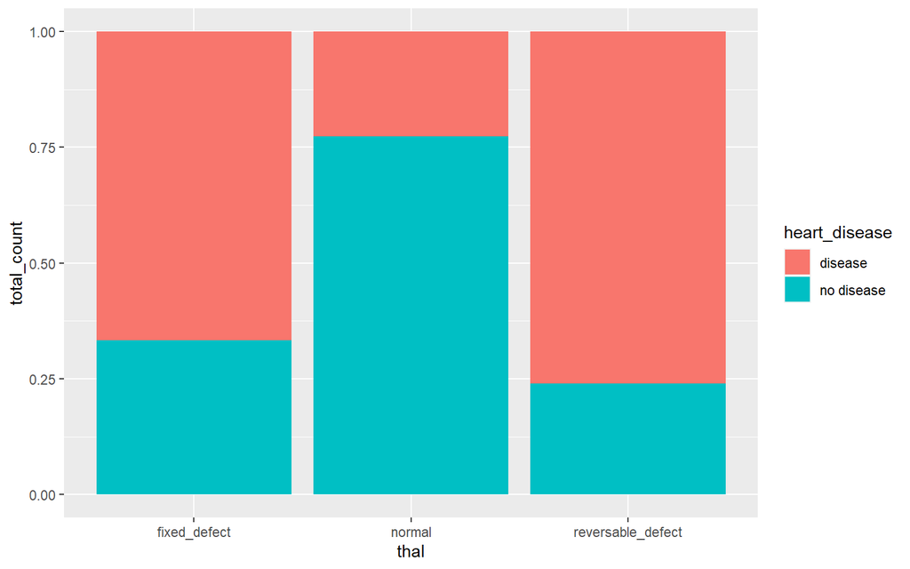

```r
groups <- c(quo(sex), quo(chest_pain_type), quo(fbs), quo(resting_ecg_results), quo(exercise_induced_angina), quo(slope), quo(num_major_vessels), quo(thal))
for (i in seq_along(groups)) {
  agg_tbl  <- datos2 %>% group_by(!!groups[[i]], heart_disease) %>% # Unquote with !!
    summarise(total_count=n())%>% as.data.frame()

  plt <- ggplot(agg_tbl,
       aes(x = !!groups[[i]], y = total_count, fill = heart_disease,label=total_count)) +
       geom_col(position = "fill")
  print(plt)
}
```